# Code snippet to the paper: Switching between different non-hierarchical administrative areas via simulated geo-coordinates: A case study for student residents in Berlin

## Case of application

The proposed method is useful for a situation where counts for a specific regional level are available with their geocoordinates but the distribution on another regional level is of interest.

In the application described in the paper “Switching between different non-hierarchical administrative areas via simulated geo-coordinates: A case study for student residents in Berlin” the numbers of students is known for the zip code level but the administration is interested in the distribution of students on a smaller regional level that is used for urban planning in Berlin, the so-called “Lebensweltlich-orientierte Räume (LOR)”.

## Data source and shape files

The data that is available is the number of students by zip code and the latitude and longitude of the center of the zip code areas. Please note that the data used in this example is random data for the student count so the results cannot be used for any analysis.

```r
dataZip <- read.csv("dataZip.csv", sep = ";")
head(dataZip)
```

```
##   Latitude Longitude Count
## 1 3.98e+14  5.82e+14   601
## 2 3.84e+14  5.82e+14    21
## 3 3.94e+14  5.82e+13   905
## 4 3.84e+13  5.81e+14  1023
## 5 4.01e+13  5.81e+14   110
## 6 3.81e+14  5.82e+14   279
```

Furthermore, the shape file for the zip codes is needed.

```r
library(rgeos)
shapefileZip <- rgdal::readOGR("RBS_OD_PLZ_2014.shp", layer="RBS_OD_PLZ_2014")
```

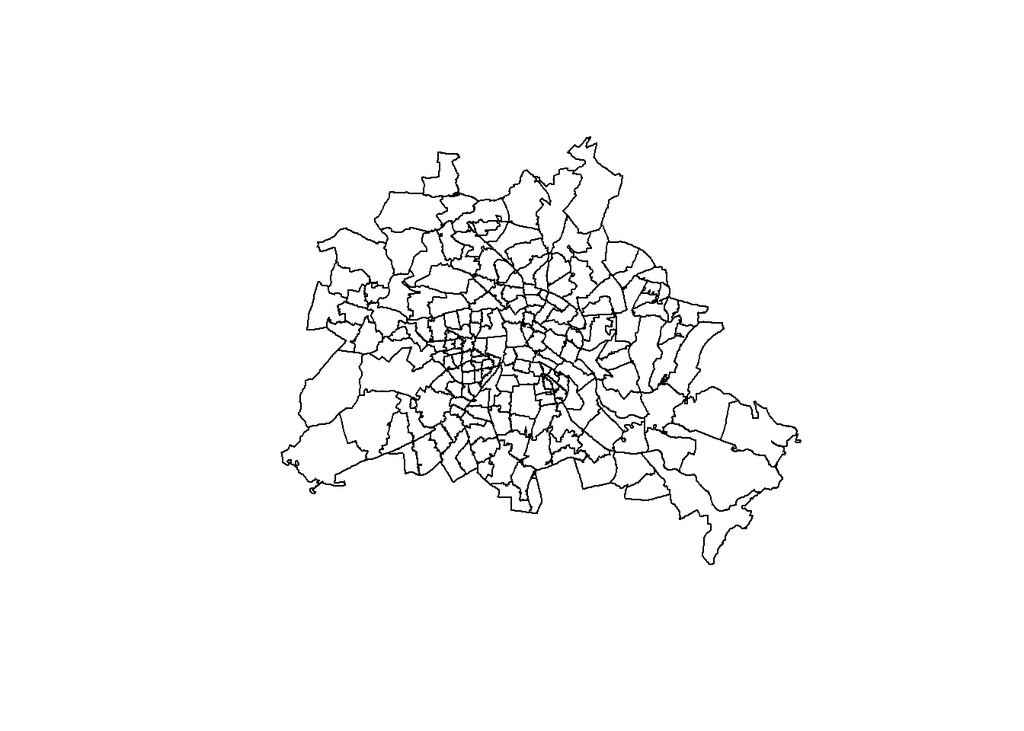

```r
plot(shapefileZip)
```

## Estimation

With the dshapebivr function of the R package Kernerlheaping, the bivariate kernel density is estimated using the available data on zip code level and the shape file.

```r
library(Kernelheaping)
Mestimates <- dshapebivr(data=dataZip, burnin=1, samples=5, shapefile= shapefileZip,
                         gridsize = 50, boundary = TRUE)
```

```
## [1] "Start Chain 1"
## [1] "Iteration: 1 of 6 in chain 1"
## [1] "Iteration: 2 of 6 in chain 1"
## [1] "Iteration: 3 of 6 in chain 1"
## [1] "Iteration: 4 of 6 in chain 1"
## [1] "Iteration: 5 of 6 in chain 1"
## [1] "Iteration: 6 of 6 in chain 1"
```

Another example up to this point is the [estimation of the density of inhabitants between a specific age group](https://www.inwt-statistics.com/read-blog/introducing-the-kernelheaping-package-ii.html). For this example, it is also shown [how to exclude uninhabited areas](https://www.inwt-statistics.com/read-blog/introducing-the-kernel-heaping-package-iii.html).

The switching from the zip code level to the LOR level is provided by function toOtherShape. The arguments are the return of the dshapebivr function and a shape file on the LOR level.

```r
shapefileLORS <- rgdal::readOGR("RBS_OD_LOR_1412.shp",layer="RBS_OD_LOR_1412")
LOREstimates <- toOtherShape(Mestimates = Mestimates, shapefile= shapefileLORS)
```

It returns the average density, standard deviation and the 0.05th and 0.95th quantile.

```r
head(LOREstimates)
```

```
##   meanCount sdCount q0.05Count q0.95Count
## 1       699       0        699        699
## 2      1658      42       1603       1696
## 3       170      17        148        187
## 4         0       0          0          0
## 5       238      11        226        250
## 6       159       5        156        166
```

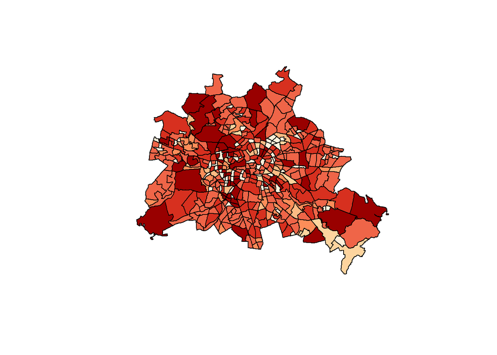

```r
plot(shapefileLORS, col = brewer.pal(7, "OrRd")[as.numeric(cut(LOREstimates$meanCount,
                                                               c(0, 10, 20, 50, 100, 500, 1000, Inf),
                                                               include.lowest = TRUE))])
```